# Social and economic networks

Handout 6

Juan José Martín y Christian Strasser

**1)** What 0.5% of the nodes do you consider more ``prestigious’’ in the WikiVote network studied in Handout 4? What kind of centrality (or centralities) do you use to measure this prestige and why?

```r
df = read.csv("datasets/WikiVote.txt", sep = "\t")
g = graph_from_data_frame(df, directed = TRUE)
```

A continuación, extraemos el 0.5% de los nodos más prestigiosos según el in-degree, ya que este tipo de centralidad representa a los nodos que han sido más votados. Esto se debe a que si un nodo ha sido muy votado, es porque es muy prestigioso.

```r
r = round(gorder(g) * 0.005)
names(round(sort(igraph::degree(g, normalized = TRUE, mode = 'in'), decreasing = TRUE), 4)[1:r])
```

```
##  [1] "4037" "15"   "2398" "2625" "1297" "2565" "762"  "2328" "5254" "3352"
## [11] "4191" "2066" "1549" "3089" "2535" "737"  "4335" "3456" "5412" "3334"
## [21] "2654" "7620" "6634" "4712" "1633" "4735" "1186" "3537" "2576" "271"
## [31] "3459" "7553" "1026" "1211" "3897" "3117"
```

No obstante, también sacamos el 0.5% de los nodos más prestigiosos mediante la centralidad eigenvector, ya que sirve para saber cuán prestigioso es un nodo mediante la influencia que tiene ese nodo en la red.

```r
r = round(gorder(g) * 0.005)
names(round(sort(eigen_centrality(g, scale = FALSE)$vector, decreasing = TRUE), 4)[1:r])
```

```
##  [1] "2565" "1549" "1166" "766"  "3352" "2688" "457"  "2485" "3456" "2328"
## [11] "1151" "1374" "2871" "11"   "5524" "2651" "2237" "2398" "737"  "3453"
## [21] "5079" "4310" "2576" "2972" "3026" "1608" "2653" "1297" "2145" "3447"
## [31] "4099" "2297" "825"  "1305" "1133" "2660"
```

**2)** What fraction of individuals in this network received less votes than the mean number of votes received by the people they voted?

```r
mean_neigh_friends = c()
dg = degree(g, mode = "in")

for (i in 1:gorder(g)) {
  neigh = neighbors(g, i, mode = "out")
  mean_neigh_friends = c(mean_neigh_friends, mean(degree(g, neigh, mode = "in") - 1))
}
```

El número y la fracción de individuos que tienen un número de votaciones más pequeño que el número medio de votaciones de aquellos que votaron:

```r
mean_neigh_friends[is.na(mean_neigh_friends)] = 0
v_mean = sum(dg < mean_neigh_friends)
v_mean
```

```
## [1] 5832
```

```r
v_mean / gorder(g)
```

```
## [1] 0.8196767
```

**3)** Consider the weighted directed network describing the main crude petrol trade among countries in 2003, downloaded from UN COMTRADE (https://comtrade.un.org/data/). The links in this network are contained in the file **WT_petrol.txt**: a link $x\to y$ with weight $w$ means that $x$ exported to $y$ for an amount of $w$ kg. The names of the countries and their ISO3 are contained in the file **Countries.txt**.

Download it on your computer and upload it to R as a dataframe. Define a directed graph with this list of arcs. Check that it is a weighted simple network.

```r
dfc = read.csv("datasets/Countries.txt", sep = " ")
dfp = read.csv("datasets/WT_petrol.txt", sep = " ")

dfp = data.frame(from=dfc[match(dfp$from, dfc$code), 'iso3'],
                 to=dfc[match(dfp$to, dfc$code), 'iso3'],
                 weight=dfp$weight)
dfp
```

| from | to | weight |
| --- | --- | --- |
| BGD | AFG | 1955451 |
| LKA | AFG | 407275 |
| CHN | AFG | 2759580 |
| DEU | AFG | 74000 |
| GTM | AFG | 153000 |
| IDN | AFG | 3056860 |
| IRN | AFG | 189817 |
| KEN | AFG | 69124368 |
| KWT | AFG | 1376 |
| KGZ | AFG | 1795687 |

[output cut: 7452 more lines]

```r
gwd = graph_from_data_frame(dfp, directed = TRUE)
```

```r
is_weighted(gwd)
```

```
## [1] TRUE
```

*a)* It is reasonable to use the weights as distances? Why? If your answer is negative, take it into account when computing centralities.

El atributo más adecuado para el peso de una arista depende del estudio que se quiere realizar sobre la red determinada. Por ejemplo, si el estudio consiste simplemente en analizar las conexiones de esta red para estudiar, por ejemplo, recorridos mínimos, la distacia es un atributo adecuado. Por otro lado, si por ejemplo se trata de analizar cuanta presión necesita cada conexión de la red, la distancia no es adecuada, porque la presión no depende únicamente de la distancia, sino también por ejemplo de la cantidad de petroleo que pasa por cada conexión.

*b)* Remove the isolated nodes from the network.

```r
components(gwd)$no
```

```
## [1] 1
```

No hace falta simplificar/eliminar nodos, ya que no hay nodos aislados.

*c)* Compute the basic indices of the resulting network’s topology: order, size, density, number of weak and strong connected components, directed and undirected diameter, undirected transitivity.

Orden y tamaño del grafo dirigido *gwd*:

```r
gorder(gwd)
```

```
## [1] 224
```

```r
ecount(gwd)
```

```
## [1] 7462
```

Densidad de *gwd*:

```r
edge_density(gwd, loops = FALSE)
```

```
## [1] 0.1493834
```

Componente conexo gigante débilmente conectado:

```r
gorder(induced_subgraph(gwd, v = groups(components(gwd, mode = "weak"))[[1]]))
```

```
## [1] 224
```

Componente conexa gigante fuertemente conectado:

```r
gorder(induced_subgraph(gwd, v = groups(components(gwd, mode = "strong"))[[1]]))
```

```
## [1] 204
```

Diámetro dirigido:

```r
diameter(gwd, directed = TRUE)
```

```
## [1] 549558
```

Diametro no dirigido:

```r
diameter(gwd, directed = FALSE)
```

```
## [1] 536755
```

Coeficiente de transitividad no dirigido:

```r
round(transitivity(gwd), 4)
```

```
## [1] 0.5394
```

*d)* What fraction of adjacent pairs are mutual (of the form $x\leftrightarrow y$)? What do mutual pairs of nodes mean, in the context of this network, and how do you consider they could affect the notion of centrality in this network?

La fracción de los nodos adjacentes es:

```r
reciprocity(gwd, ignore.loops = TRUE)
```

```
## [1] 0.4835165
```

Una conexión mútua en esta red significa que hay dos conexiones petrolíferas entre estos paises, dado que estas conexiones tienen pesos diferentes. Aún con pesos iguales supondriamos que se trata de dos conexiones diferentes dado que es imposible (por temas de física…) tener una misma conexión que transporta petroleo en ambas direcciones.

Por el tema de centralidad, tener un conjunto de nodos que están enlazados entre ellos en ambas direcciones causaría que, para cualquier estudio de centralidad, el valor de estos nodos incrementaría.

*e)* There is one “important” type of centrality that is not relevant in this network. Which one and why?

Por definición propia del tipo de centralidad, la ‘Betweenness’ no tiene sentido en una red que muestra el tráfico petrolífero entre paises. Si un país ‘A’ está conectado en esta red con un país ‘B’ y, a su vez, el país ‘B’ está conectado con un país ‘C’, no significa que el país ‘A’ está realizando comercio de petroleo con el país ‘C’. Por esto, darle más importancia a nodos intermedios no tiene sentido en esta red.

*f)* What are the 5% most central nodes in this network according to the different sensible and relevant centrality indices discussed in the course? (Remember to distinguish between incoming arcs and outcoming arcs, and recall that the network is weighted.) Comment the results, including the meaning of the centralities used in the context of this network and why you use them.

```r
r = round(gorder(gwd) * 0.05)

Cent.Deg.in = round(sort(degree(gwd, mode = "in"),
                       decreasing = TRUE), 4)[1:r]

Cent.Deg.out = round(sort(degree(gwd, mode = "out"),
                        decreasing = TRUE), 4)[1:r]

Cent.Str.in = round(sort(strength(gwd, mode = "in"),
                       decreasing = TRUE), 4)[1:r]

Cent.Str.out = round(sort(strength(gwd, mode = "out"),
                        decreasing = TRUE), 4)[1:r]

Cent.Clo.in = round(sort(estimate_closeness(gwd, normalized = TRUE,
                                          weights = 1/edge_attr(gwd)$weight,
                                          cutoff = 10, mode = "in"),
                       decreasing = TRUE), 4)[1:r]

Cent.Clo.out = round(sort(estimate_closeness(gwd, normalized = TRUE,
                                           weights = 1/edge_attr(gwd)$weight,
                                           cutoff = 10, mode = "out"),
                        decreasing = TRUE), 4)[1:r]

Cent.Eig = round(sort(eigen_centrality(gwd,
                                       weights = edge_attr(gwd)$weight)$vector,
                      decreasing =TRUE),4)[1:r]
```

```r
DEG.in = attr(Cent.Deg.in, "names")
DEG.out = attr(Cent.Deg.out, "names")
STR.in = attr(Cent.Str.in, "names")
STR.out = attr(Cent.Str.out, "names")
CLO.in = attr(Cent.Clo.in, "names")
CLO.out = attr(Cent.Clo.out, "names")
Eig = attr(Cent.Eig, "names")

Most.central = data.frame(DEG.in, DEG.out, STR.in, STR.out, CLO.in, CLO.out, Eig)
names(Most.central) = c("Degree In", "Degree Out", "Strength In",
                        "Strength Out", "Clos. In", "Clos. Out", "Eigenv.")
row.names(Most.central) = 1:r
Most.central
```

| Degree In | Degree Out | Strength In | Strength Out | Clos. In | Clos. Out | Eigenv. |
| --- | --- | --- | --- | --- | --- | --- |
| USA | IND | USA | BRA | LBY | RWA | USA |
| DEU | LKA | DEU | COL | GIB | IDN | DEU |
| FRA | IDN | JPN | DEU | BMU | VNM | BRA |
| CAN | CHN | FRA | IND | VAT | IND | COL |
| NULL | DEU | GBR | IDN | SGS | CHN | CAN |
| GBR | ITA | CAN | VNM | FSM | PNG | IDN |
| NLD | GBR | NLD | CHN | SLB | LKA | FRA |
| ITA | USA | ITA | LKA | WLF | BRA | ITA |
| ESP | NULL | BEL | KEN | KIR | COM | JPN |
| AUS | FRA | ESP | GTM | ASM | TZA | GTM |

[output cut: 1 more lines]

Con la anterior tabla se puede observar que USA, DEU, FRA, GBR, NLD, ITA y ESP son los países que reciben petróleo de más países (Degree In) y, además, en mayor cantidad (Strength In: tiene en cuenta el número de grados y el peso de las aristas entrantes). Por otro lado, tenemos que IND, LA, IDN, DEU, ITA, GBR, USA y FRA son países que exportan a una mayor cantidad de países (Degree Out), pero no todos son los que mayor cantidad de petróleo exportan. Por ejemplo, en el caso de BRA, se podría concluir que exporta mucho petróleo a una cantidad menor de países, igual que COL o GTM (Strength Out).

*g)* What are the Spearman correlations between the centralities computed in the previous point? Do these centralities sort the countries in a similar way?

```r
Spe.DEG.in = degree(gwd, mode = "in")
Spe.DEG.out = degree(gwd, mode = "out")
Spe.STR.in = strength(gwd, mode = "in")
Spe.STR.out = strength(gwd, mode = "out")
Spe.CLO.in = estimate_closeness(gwd, normalized = TRUE,
                            weights = 1/edge_attr(gwd)$weight,
                            cutoff = 10, mode = "in")
Spe.CLO.out = estimate_closeness(gwd, normalized = TRUE,
                            weights = 1/edge_attr(gwd)$weight,
                            cutoff = 10, mode = "out")
Spe.Eig = eigen_centrality(gwd,
                       weights = edge_attr(gwd)$weight)$vector

Centralities = data.frame(Spe.DEG.in, Spe.DEG.out, Spe.STR.in,
                     Spe.STR.out, Spe.CLO.in, Spe.CLO.out, Spe.Eig)
names(Centralities) = c("Degree In", "Degree Out", "Strength In",
                        "Strength Out", "Clos. In", "Clos. Out", "Eigenv.")

kable(round(cor(Centralities, method = "spearman"), 4))
```

|  | Degree In | Degree Out | Strength In | Strength Out | Clos. In | Clos. Out | Eigenv. |
| --- | --- | --- | --- | --- | --- | --- | --- |
| Degree In | 1.0000 | 0.7489 | 0.8905 | 0.6629 | 0.3713 | 0.5776 | 0.7968 |
| Degree Out | 0.7489 | 1.0000 | 0.6899 | 0.9513 | 0.0828 | 0.9017 | 0.9142 |
| Strength In | 0.8905 | 0.6899 | 1.0000 | 0.6251 | 0.5036 | 0.5349 | 0.7894 |
| Strength Out | 0.6629 | 0.9513 | 0.6251 | 1.0000 | 0.0188 | 0.9763 | 0.9093 |
| Clos. In | 0.3713 | 0.0828 | 0.5036 | 0.0188 | 1.0000 | -0.0670 | 0.2514 |
| Clos. Out | 0.5776 | 0.9017 | 0.5349 | 0.9763 | -0.0670 | 1.0000 | 0.8630 |
| Eigenv. | 0.7968 | 0.9142 | 0.7894 | 0.9093 | 0.2514 | 0.8630 | 1.0000 |

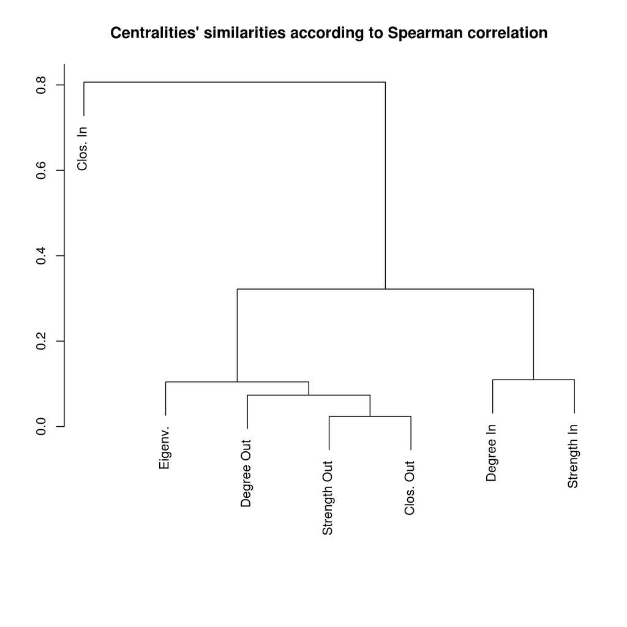

```r
plot(hclust(as.dist(1 - cor(Centralities, method = "spearman")), method = "average"),
     main = "Centralities' similarities according to Spearman correlation",
     xlab = "", ylab = "", sub = "")
```

*h)* What would you consider the 5% most important nodes in this network? Explain your decision.

```r
STR.out
```

```
##  [1] "BRA" "COL" "DEU" "IND" "IDN" "VNM" "CHN" "LKA" "KEN" "GTM" "USA"
```

Consideramos el 5% de nodos más importantes aquellos que exportan una mayor cantidad de petróleo, ya que Strength Out tiene en cuenta el peso de las aristas. De esta forma podríamos examinar, por ejemplo, por qué a un país le compran tanto petróleo (precios más baratos, fronteras más abiertas, etc.).

*i)* Plot the induced subgraph supported on the set of countries consisting of the union of the 5% most central nodes w.r.t. in-strength and the 5% most central nodes w.r.t. out-strength. The size of the nodes must represent some sensible centrality (choose which one and justify your choice) and the width of the arrows their weight.

```r
STR_most_central_nodes = unique(c(STR.in, STR.out))
V(gwd)$vertex_strength = strength(gwd, mode = 'out')
STR_g_ind = induced_subgraph(gwd, v = STR_most_central_nodes)
```

Elegimos la centralidad out-strength para representar el tamaño de los nodos por el motivo explicado en el apartado anterior. De esta forma podremos analizar gráficamente qué países exportan una mayor cantidad de petróleo.

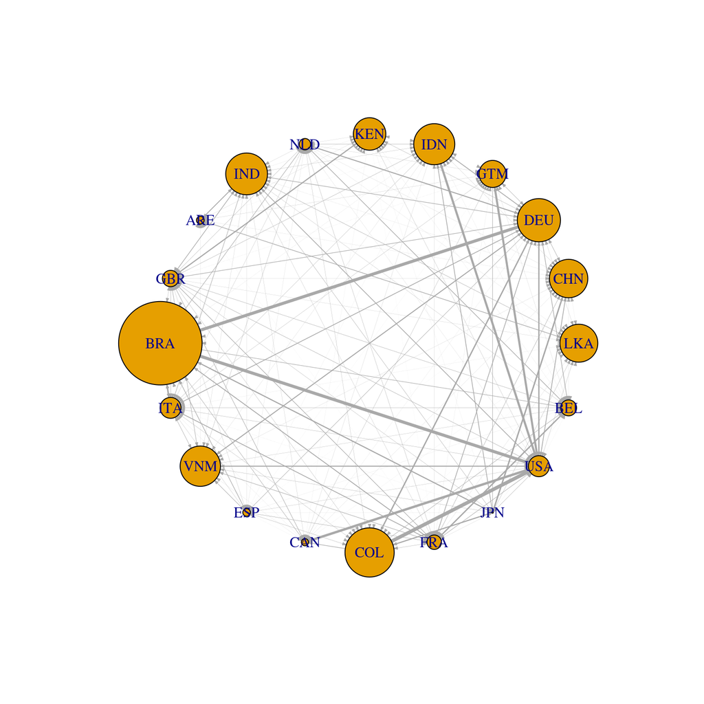

```r
plot(STR_g_ind,
     edge.width = E(STR_g_ind)$weight * 0.00000001,
     edge.arrow.size = 0.2,
     vertex.size = V(STR_g_ind)$vertex_strength * 0.000000023,
     layout=layout_in_circle)
```

*j)* Is this network robust against the removal of a few central nodes?

```r
DEG.in.comp = components(delete.vertices(gwd, DEG.in))$no
DEG.out.comp = components(delete.vertices(gwd, DEG.out))$no
STR.in.comp = components(delete.vertices(gwd, STR.in))$no
STR.out.comp = components(delete.vertices(gwd, STR.out))$no
CLO.in.comp = components(delete.vertices(gwd, CLO.in))$no
CLO.out.comp = components(delete.vertices(gwd, CLO.out))$no
Eig.comp = components(delete.vertices(gwd, Eig))$no

Comp.central = data.frame(DEG.in.comp, DEG.out.comp, STR.in.comp,
                          STR.out.comp, CLO.in.comp, CLO.out.comp, Eig.comp)
names(Comp.central) = c("Degree In", "Degree Out", "Strength In",
                        "Strength Out", "Clos. In", "Clos. Out", "Eigenv.")
row.names(Comp.central) = 1:1
Comp.central
```

| Degree In | Degree Out | Strength In | Strength Out | Clos. In | Clos. Out | Eigenv. |
| --- | --- | --- | --- | --- | --- | --- |
| 3 | 5 | 3 | 4 | 1 | 4 | 4 |

A partir de los números relativamente bajos de la tabla anterior, podemos considerar esta red bastante robusta a la eliminación de nodos centrales.